# Lab 3.2

Данилов Никита

Файл ExpImp.RData. Приведите данные к формату tidydata. Отобразите значения суммарного экспорта и импорта по регионам в виде столбчатой диаграммы [сгруппировав значения по названию региона]. Экспорт и импорт обозначьте разными цветами. Сделайте второй график, на котором значения экспорта и импорта расположите по разные стороны относительно оси x. Подпишите величины экспорта и импорта.

## Solution

Загрузим необходимые библиотеки и исходные данные

Преобразуем данные к формату tidydata. А такаже избавимся от совокупных значений – Российская федерация, округа и т.п.

```r
load("ExpImp.RData")
expimp = tibble(ExpImp[-grep('Российская Федерация|округ|в том числе:', ExpImp$Регион),])
expimp[2:13] = lapply(expimp[2:13], function(x) as.numeric(sub('-', '0.', x)))
```

Выделим столбцы с импортом и экспортом

```r
exp <- grep('.*Экспорт', colnames(expimp))
imp <- grep('.*Импорт', colnames(expimp))
expimp <- expimp %>%
    mutate(Суммарный_экспорт = select(., exp) %>% rowSums(na.rm = TRUE)) %>%
    mutate(Суммарный_импорт = select(., imp) %>% rowSums(na.rm = TRUE))
head(expimp)
```

| Регион | ПродЭкспорт | ПродИмпорт | ТЭКЭкспорт | ТЭКИмпорт | ХимЭкспорт | ХимИмпорт | ДревЭкспорт | ДревИмпорт | МетЭкспорт | МетИмпорт | МашЭкспорт | МашИмпорт | Суммарный_экспорт | Суммарный_импорт |
| --- | --- | --- | --- | --- | --- | --- | --- | --- | --- | --- | --- | --- | --- | --- |
| Белгородская область | 221.9 | 613.8 | 64.7 | 24.1 | 33.3 | 242.8 | 6.2 | 43.3 | 2014.1 | 1207.3 | 84.1 | 1709.7 | 2424.3 | 3841.0 |
| Брянская область | 28.5 | 650.3 | 5.0 | 20.5 | 24.5 | 71.7 | 23.4 | 44.9 | 50.5 | 68.3 | 143.2 | 823.1 | 275.1 | 1678.8 |
| Владимирская область | 177.9 | 454.3 | 0.9 | 16.7 | 87.7 | 419.0 | 57.1 | 9.0 | 29.0 | 56.6 | 286.1 | 468.7 | 638.7 | 1424.3 |
| Воронежская область | 373.7 | 181.9 | 38.9 | 38.0 | 976.9 | 84.9 | 10.1 | 15.8 | 42.2 | 121.4 | 111.8 | 671.6 | 1553.6 | 1113.6 |
| Ивановская область | 3.1 | 105.5 | 0.1 | 0.1 | 40.8 | 57.4 | 8.8 | 55.2 | 3.0 | 44.9 | 52.7 | 226.4 | 108.5 | 489.5 |
| Калужская область | 20.9 | 184.6 | 14.0 | 57.9 | 54.9 | 370.3 | 39.5 | 73.7 | 70.0 | 615.5 | 474.1 | 5950.6 | 673.4 | 7252.6 |

Изменим имя столбца для удобства и оставим только необходимые столбцы. Далее соединим два последних столбца в один и добавим тип значения: импорт или экспорт.

Строим стобчатую диаграмму с показателями импорта и экспорта по регионам.

```r
colnames(expimp)[1] <- "Region"
expimp <- expimp[c(1, 14, 15)]
head(expimp)
```

| Region | Суммарный_экспорт | Суммарный_импорт |
| --- | --- | --- |
| Белгородская область | 2424.3 | 3841.0 |
| Брянская область | 275.1 | 1678.8 |
| Владимирская область | 638.7 | 1424.3 |
| Воронежская область | 1553.6 | 1113.6 |
| Ивановская область | 108.5 | 489.5 |
| Калужская область | 673.4 | 7252.6 |

```r
expimp2 <- tibble(melt(data.table(expimp), id.vars="Region"))
head(expimp2)
```

| Region | variable | value |
| --- | --- | --- |
| Белгородская область | Суммарный_экспорт | 2424.3 |
| Брянская область | Суммарный_экспорт | 275.1 |
| Владимирская область | Суммарный_экспорт | 638.7 |
| Воронежская область | Суммарный_экспорт | 1553.6 |
| Ивановская область | Суммарный_экспорт | 108.5 |
| Калужская область | Суммарный_экспорт | 673.4 |

```r
plot <- ggplot(expimp2, aes(x=value, y=Region, fill=variable)) +
  geom_bar(stat='identity', position='dodge') + xlab("Регион") + ylab("Объем") +
  ggtitle("Объем экспорта по регионам") +
  scale_fill_discrete(name = "Экспорт/Импорт") + theme(text = element_text(size=16),
        axis.text.x = element_text(angle=0, hjust=0.5, vjust = 0.5),
        axis.text.y = element_text(hjust=1, vjust = 0.4))
```

Выведем получившуюся диаграмму

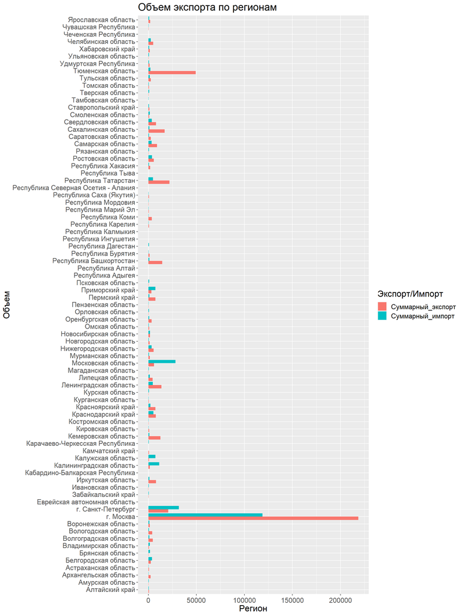

```r
plot
```

Построим другую столбчатую диаграмму, у которой значения находятся по разные стороны относительно оси x. Для большей наглядности в этой гистограмме перейдем не к логарифму значений, как принято делать, а к корню 4 степени - теперь данные удобно сравнивать относительно друг друга, а близкие к нулю значения не дадут некорректные значения - величины стремящиеся к минус бесконечности.

```r
logexpimp <- expimp
logexpimp$Суммарный_экспорт = -1*(expimp$Суммарный_экспорт^(1/4))
logexpimp$Суммарный_импорт = expimp$Суммарный_импорт^(1/4)
expimp3 <- tibble(melt(data.table(logexpimp), id.vars="Region"))
```

Регионов много, чтобы все уместить на горизонатальной гистограмме - поменяем оси X и Y местами. Также добавим подписи к столбцам в абсолютных величинах экспорта/импорта.

```r
plot2 <- ggplot(expimp3, aes(x=value, y=Region, fill=variable)) +
  geom_bar(stat='identity') + xlab("Регион") + ylab("Объем") +
  ggtitle("Объем экспорта по регионам") +
  geom_text(aes(label=ifelse(variable=="Суммарный_экспорт",
                             expimp$Суммарный_экспорт,
                             expimp$Суммарный_импорт),
                position = ifelse(variable=="Суммарный_экспорт", 0, 1))) +
  scale_fill_discrete(name = "Экспорт/Импорт") +
  theme(text = element_text(size=15),
        axis.text.x = element_text(angle=0, hjust=0.5, vjust = 0.5),
        axis.text.y = element_text(hjust=1, vjust = 0.4))
```

Выведем получившуюся диаграмму

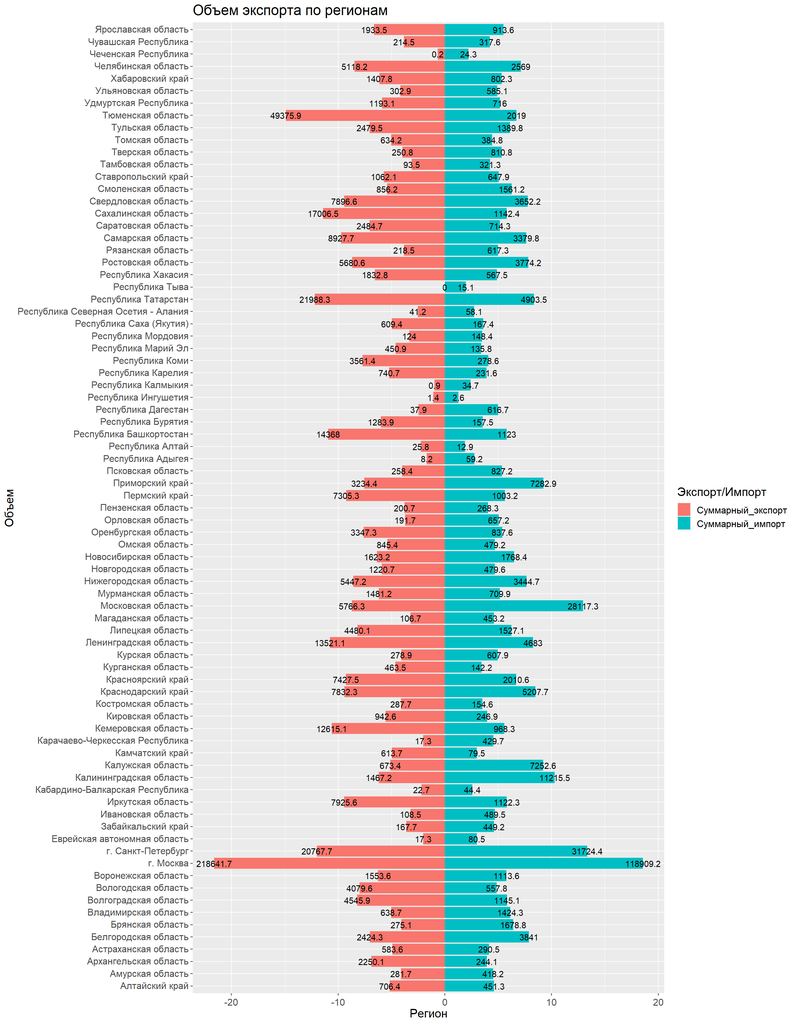

```r
plot2
```